# Eflows Species Clustering in CA Regions

## Overview and Basic Methods

In this version (June 2018) of the clustering, translocations were *not* included. Clusters must be contiguous in this version, as determined by a shared boundary or vertex, not by hydrologic connectivity. All HUCs were included, regardless of the minimum number of taxa (includes ones with one or none). Clustering was done with Flow Sensitive Taxa.

Clustering was done by a PISCES tool that subsets and formulates the data to be used by ArcGIS’ Grouping Analysis tool, where prior versions were clustered through manual steps and then fed into GeoDa’s K-Means tool.

## Map of Region Breakouts

The region was broken out primarily into * North Coast (North Coast->San Francisco) * South Coast (South of SF -> Southern California) * Central Valley (anything draining out through the Central Valley - excludes Honey/Eagle Lakes and SF Bay) * Great Basin (anything in hydrologic region 16 in the northern part of the state, contiguous) * Desert - not clustered or shown here as previous clustering indicated single-species driven areas (Includes eastern sierra that is part of region 18, souther reaches of region 15 in the state, portion of Colorado River, and a small piece of region 16)

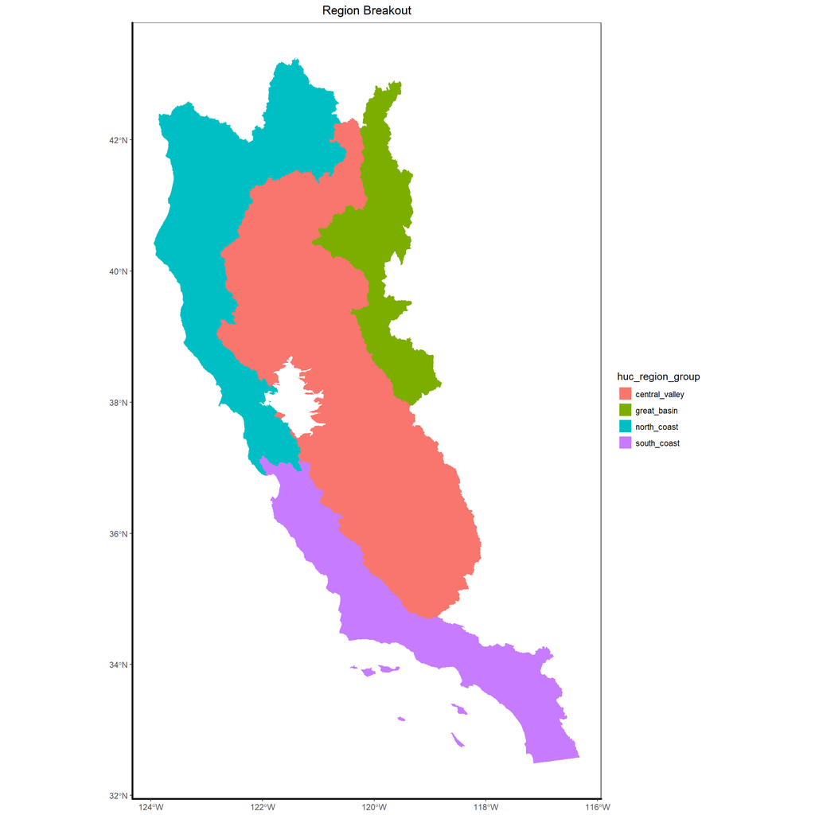

```r
writeLines("td, th { padding : 6px } th { background-color : #fff ; color : #000; border : 1px solid #333; } td { color : #000 ; border : 1px solid #333 }", con = "mystyle.css")  # add the CSS for the data tables

ggplot() +
  geom_sf(huc_data, lwd = 5, mapping=aes(fill=huc_region_group), color=NA)+
  ggtitle("Region Breakout") +
  theme_bw()+
  theme(panel.grid.major = element_line(colour = 'transparent'))+
  theme(strip.background = element_blank(), # facet theme control
        strip.placement = "outside",
        axis.line.x = element_line(color="black", size = 1),
        axis.line.y = element_line(color="black", size = 1),
        plot.title = element_text(hjust = 0.5))
```

## Central Valley

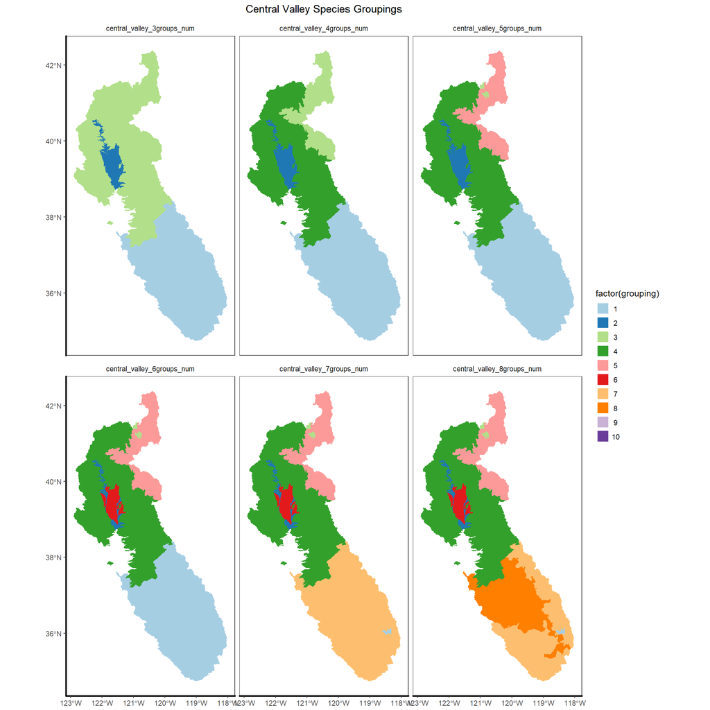

```r
cv_region_name = "central_valley"
cv_species_info <- species_maps(cv_region_name, "Central Valley", huc_data)
cv_species_info$region_map  # print the map
```

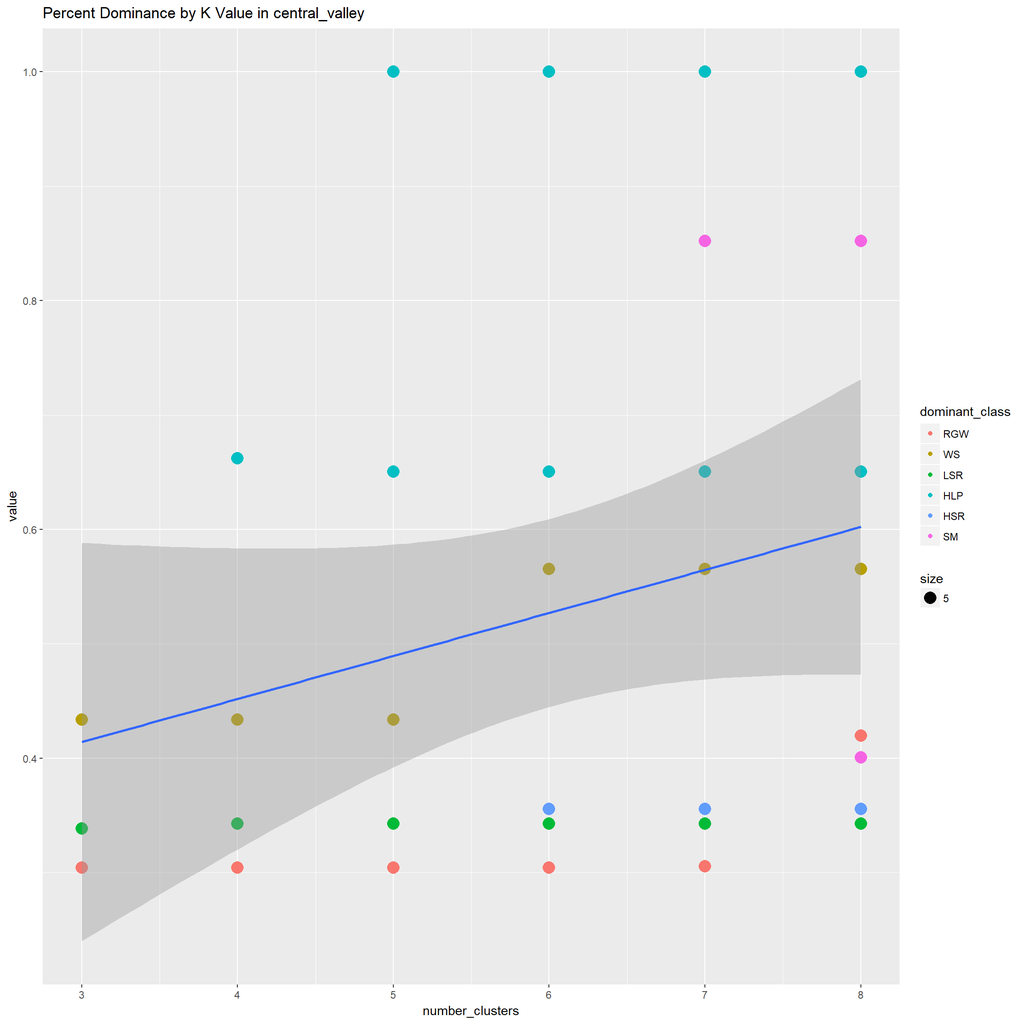

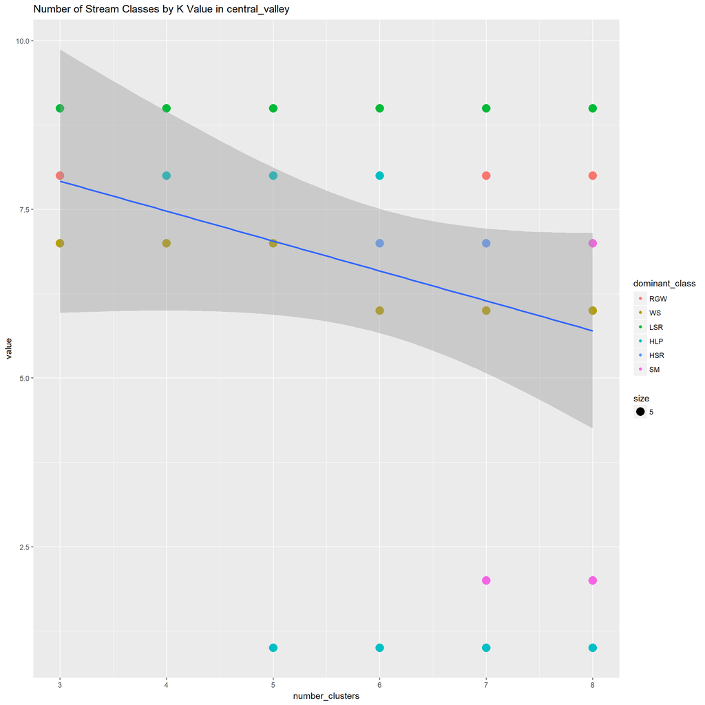

```r
print_dominance_plots(cv_species_info, cv_region_name)
```

```r
cv_species_lists <- species_lists_by_group_dfs(cv_species_info$species_data, cv_region_name)  # species_info$species_data is the data frame for the region
for(df in cv_species_lists){
  show(knitr::kable(df, format="html"))
}
```

| group_1 | group_2 | group_3 |
| --- | --- | --- |
| aculeatus | aculeatus | aculeatus |
| conocephalus | ayersi | ayersi |
| exilicauda | conocephalus | conocephalus |
| grandis | exilicauda | exilicauda |
| gulosus | grandis | grandis |
| hubbsi | gulosus | gulosus |
| macrolepidotus | macrolepidotus | hubbsi |
| mykiss | medirostris | klamathensis |
| occidentalis | occidentalis | macrolepidotus |
| symmetricus | osculus | medirostris |
| tridentata | richardsoni | microps |
| tshawytscha | symmetricus | occidentalis |
| NA | transmontanus | osculus |
| NA | traskii | pitensis |
| NA | tridentata | richardsoni |
| NA | tshawytscha | symmetricus |
| NA | NA | transmontanus |
| NA | NA | traskii |
| NA | NA | tridentata |
| NA | NA | tshawytscha |

| group_1 | group_2 | group_3 | group_4 |
| --- | --- | --- | --- |
| aculeatus | aculeatus | conocephalus | aculeatus |
| conocephalus | ayersi | grandis | ayersi |
| exilicauda | conocephalus | microps | conocephalus |
| grandis | exilicauda | occidentalis | exilicauda |
| gulosus | grandis | osculus | grandis |
| hubbsi | gulosus | pitensis | gulosus |
| macrolepidotus | macrolepidotus | symmetricus | hubbsi |
| mykiss | medirostris | NA | klamathensis |
| occidentalis | occidentalis | NA | macrolepidotus |
| symmetricus | osculus | NA | medirostris |
| tridentata | richardsoni | NA | occidentalis |
| tshawytscha | symmetricus | NA | osculus |
| NA | transmontanus | NA | pitensis |
| NA | traskii | NA | richardsoni |
| NA | tridentata | NA | symmetricus |
| NA | tshawytscha | NA | transmontanus |
| NA | NA | NA | traskii |
| NA | NA | NA | tridentata |
| NA | NA | NA | tshawytscha |

| group_1 | group_2 | group_3 | group_4 | group_5 |
| --- | --- | --- | --- | --- |
| aculeatus | aculeatus | conocephalus | aculeatus | conocephalus |
| conocephalus | ayersi | grandis | ayersi | grandis |
| exilicauda | conocephalus | microps | conocephalus | occidentalis |
| grandis | exilicauda | occidentalis | exilicauda | osculus |
| gulosus | grandis | osculus | grandis | pitensis |
| hubbsi | gulosus | pitensis | gulosus | symmetricus |
| macrolepidotus | macrolepidotus | symmetricus | hubbsi | NA |
| mykiss | medirostris | NA | klamathensis | NA |
| occidentalis | occidentalis | NA | macrolepidotus | NA |
| symmetricus | osculus | NA | medirostris | NA |
| tridentata | richardsoni | NA | occidentalis | NA |
| tshawytscha | symmetricus | NA | osculus | NA |
| NA | transmontanus | NA | pitensis | NA |
| NA | traskii | NA | richardsoni | NA |
| NA | tridentata | NA | symmetricus | NA |
| NA | tshawytscha | NA | transmontanus | NA |
| NA | NA | NA | traskii | NA |
| NA | NA | NA | tridentata | NA |
| NA | NA | NA | tshawytscha | NA |

| group_1 | group_2 | group_3 | group_4 | group_5 | group_6 |
| --- | --- | --- | --- | --- | --- |
| aculeatus | aculeatus | conocephalus | aculeatus | conocephalus | aculeatus |
| conocephalus | ayersi | grandis | ayersi | grandis | ayersi |
| exilicauda | conocephalus | microps | conocephalus | occidentalis | conocephalus |
| grandis | exilicauda | occidentalis | exilicauda | osculus | exilicauda |
| gulosus | grandis | osculus | grandis | pitensis | grandis |
| hubbsi | gulosus | pitensis | gulosus | symmetricus | gulosus |
| macrolepidotus | macrolepidotus | symmetricus | hubbsi | NA | macrolepidotus |
| mykiss | medirostris | NA | klamathensis | NA | medirostris |
| occidentalis | occidentalis | NA | macrolepidotus | NA | occidentalis |
| symmetricus | osculus | NA | medirostris | NA | osculus |
| tridentata | richardsoni | NA | occidentalis | NA | richardsoni |
| tshawytscha | symmetricus | NA | osculus | NA | symmetricus |
| NA | transmontanus | NA | pitensis | NA | traskii |
| NA | traskii | NA | richardsoni | NA | tridentata |
| NA | tridentata | NA | symmetricus | NA | tshawytscha |
| NA | tshawytscha | NA | transmontanus | NA | NA |
| NA | NA | NA | traskii | NA | NA |
| NA | NA | NA | tridentata | NA | NA |
| NA | NA | NA | tshawytscha | NA | NA |

| group_1 | group_2 | group_3 | group_4 | group_5 | group_6 | group_7 |
| --- | --- | --- | --- | --- | --- | --- |
| grandis | aculeatus | conocephalus | aculeatus | conocephalus | aculeatus | aculeatus |
| mykiss | ayersi | grandis | ayersi | grandis | ayersi | conocephalus |
| occidentalis | conocephalus | microps | conocephalus | occidentalis | conocephalus | exilicauda |
| symmetricus | exilicauda | occidentalis | exilicauda | osculus | exilicauda | grandis |
| NA | grandis | osculus | grandis | pitensis | grandis | gulosus |
| NA | gulosus | pitensis | gulosus | symmetricus | gulosus | hubbsi |
| NA | macrolepidotus | symmetricus | hubbsi | NA | macrolepidotus | macrolepidotus |
| NA | medirostris | NA | klamathensis | NA | medirostris | mykiss |
| NA | occidentalis | NA | macrolepidotus | NA | occidentalis | occidentalis |
| NA | osculus | NA | medirostris | NA | osculus | symmetricus |
| NA | richardsoni | NA | occidentalis | NA | richardsoni | tridentata |
| NA | symmetricus | NA | osculus | NA | symmetricus | tshawytscha |
| NA | transmontanus | NA | pitensis | NA | traskii | NA |
| NA | traskii | NA | richardsoni | NA | tridentata | NA |
| NA | tridentata | NA | symmetricus | NA | tshawytscha | NA |
| NA | tshawytscha | NA | transmontanus | NA | NA | NA |
| NA | NA | NA | traskii | NA | NA | NA |
| NA | NA | NA | tridentata | NA | NA | NA |
| NA | NA | NA | tshawytscha | NA | NA | NA |

| group_1 | group_2 | group_3 | group_4 | group_5 | group_6 | group_7 | group_8 |
| --- | --- | --- | --- | --- | --- | --- | --- |
| grandis | aculeatus | conocephalus | aculeatus | conocephalus | aculeatus | conocephalus | aculeatus |
| mykiss | ayersi | grandis | ayersi | grandis | ayersi | grandis | conocephalus |
| occidentalis | conocephalus | microps | conocephalus | occidentalis | conocephalus | gulosus | exilicauda |
| symmetricus | exilicauda | occidentalis | exilicauda | osculus | exilicauda | mykiss | grandis |
| NA | grandis | osculus | grandis | pitensis | grandis | occidentalis | gulosus |
| NA | gulosus | pitensis | gulosus | symmetricus | gulosus | symmetricus | hubbsi |
| NA | macrolepidotus | symmetricus | hubbsi | NA | macrolepidotus | NA | macrolepidotus |
| NA | medirostris | NA | klamathensis | NA | medirostris | NA | occidentalis |
| NA | occidentalis | NA | macrolepidotus | NA | occidentalis | NA | symmetricus |
| NA | osculus | NA | medirostris | NA | osculus | NA | tridentata |
| NA | richardsoni | NA | occidentalis | NA | richardsoni | NA | tshawytscha |
| NA | symmetricus | NA | osculus | NA | symmetricus | NA | NA |
| NA | transmontanus | NA | pitensis | NA | traskii | NA | NA |
| NA | traskii | NA | richardsoni | NA | tridentata | NA | NA |
| NA | tridentata | NA | symmetricus | NA | tshawytscha | NA | NA |
| NA | tshawytscha | NA | transmontanus | NA | NA | NA | NA |
| NA | NA | NA | traskii | NA | NA | NA | NA |
| NA | NA | NA | tridentata | NA | NA | NA | NA |
| NA | NA | NA | tshawytscha | NA | NA | NA | NA |

## Great Basin

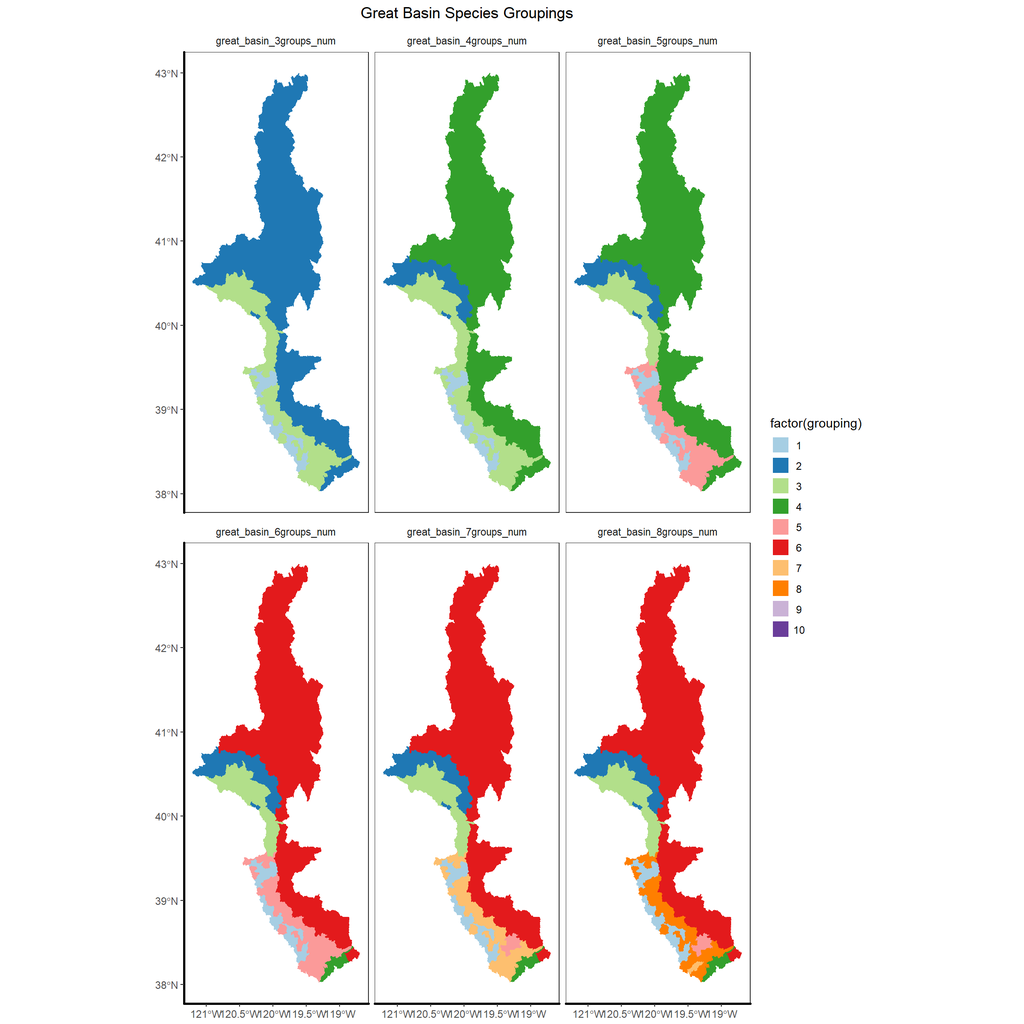

```r
gb_region_name <- "great_basin"
gb_species_info <- species_maps(gb_region_name, "Great Basin", huc_data)
gb_species_info$region_map  # print the map
```

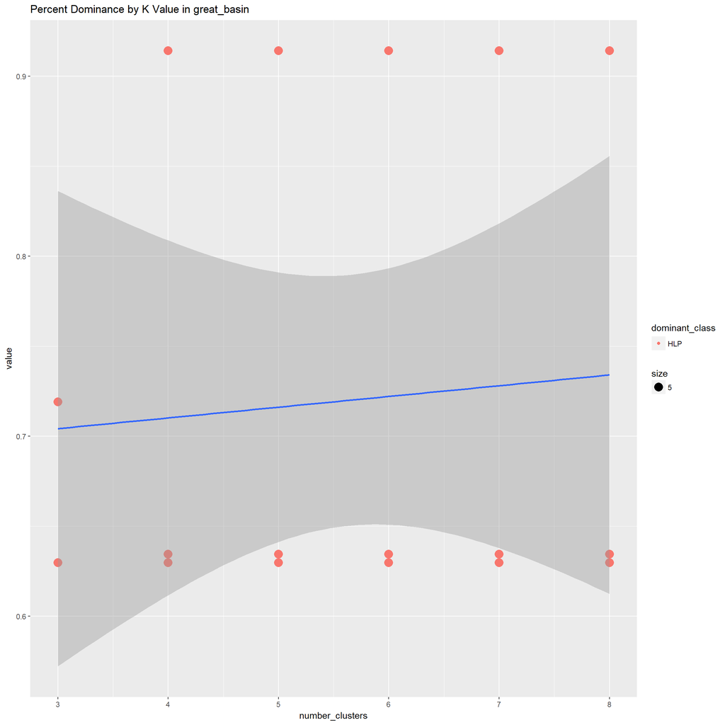

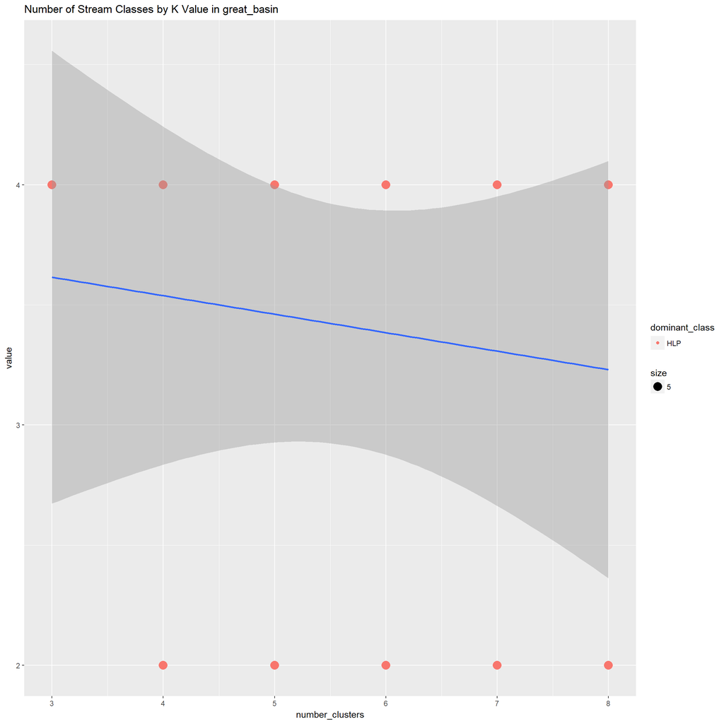

```r
print_dominance_plots(gb_species_info, gb_region_name)
```

```r
gb_species_lists <- species_lists_by_group_dfs(gb_species_info$species_data, gb_region_name)  # species_info$species_data is the data frame for the region
for(df in gb_species_lists){
  show(knitr::kable(df, format="html"))
}
```

| group_1 | group_2 | group_3 |
| --- | --- | --- |
| clarki | lahontan | clarki |
| lahontan | osculus | lahontan |
| osculus | NA | osculus |
| williamsoni | NA | williamsoni |

| group_1 | group_2 | group_3 | group_4 |
| --- | --- | --- | --- |
| clarki | osculus | clarki | lahontan |
| lahontan | NA | lahontan | osculus |
| osculus | NA | osculus | NA |
| williamsoni | NA | williamsoni | NA |

| group_1 | group_2 | group_3 | group_4 | group_5 |
| --- | --- | --- | --- | --- |
| clarki | osculus | lahontan | lahontan | clarki |
| lahontan | NA | osculus | osculus | lahontan |
| osculus | NA | NA | NA | osculus |
| williamsoni | NA | NA | NA | williamsoni |

| group_1 | group_2 | group_3 | group_4 | group_5 | group_6 |
| --- | --- | --- | --- | --- | --- |
| clarki | osculus | lahontan | lahontan | clarki | osculus |
| lahontan | NA | osculus | osculus | lahontan | NA |
| osculus | NA | NA | NA | osculus | NA |
| williamsoni | NA | NA | NA | williamsoni | NA |

| group_1 | group_2 | group_3 | group_4 | group_5 | group_6 | group_7 |
| --- | --- | --- | --- | --- | --- | --- |
| clarki | osculus | lahontan | lahontan | lahontan | osculus | clarki |
| lahontan | NA | osculus | osculus | osculus | NA | lahontan |
| osculus | NA | NA | NA | NA | NA | osculus |
| williamsoni | NA | NA | NA | NA | NA | williamsoni |

| group_1 | group_2 | group_3 | group_4 | group_5 | group_6 | group_7 | group_8 |
| --- | --- | --- | --- | --- | --- | --- | --- |
| clarki | osculus | lahontan | lahontan | lahontan | osculus | clarki | clarki |
| lahontan | NA | osculus | osculus | osculus | NA | lahontan | lahontan |
| osculus | NA | NA | NA | NA | NA | osculus | osculus |
| williamsoni | NA | NA | NA | NA | NA | williamsoni | williamsoni |

## North Coast

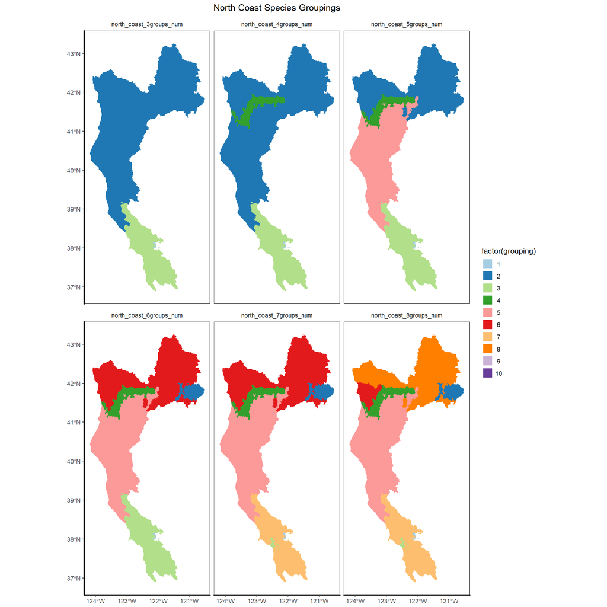

```r
coast_region_name = "north_coast"
coast_species_info <- species_maps(coast_region_name, "North Coast", huc_data)
coast_species_info$region_map  # print the map
```

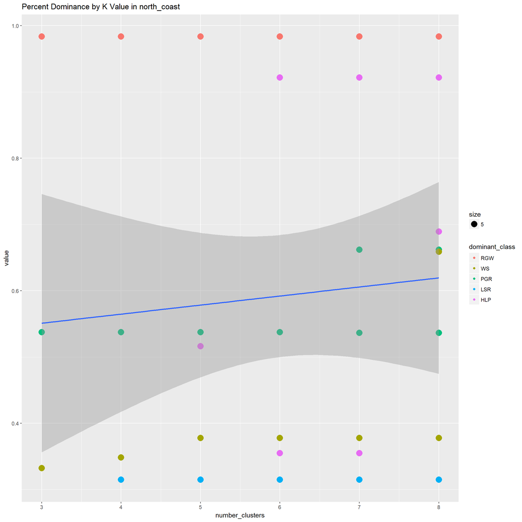

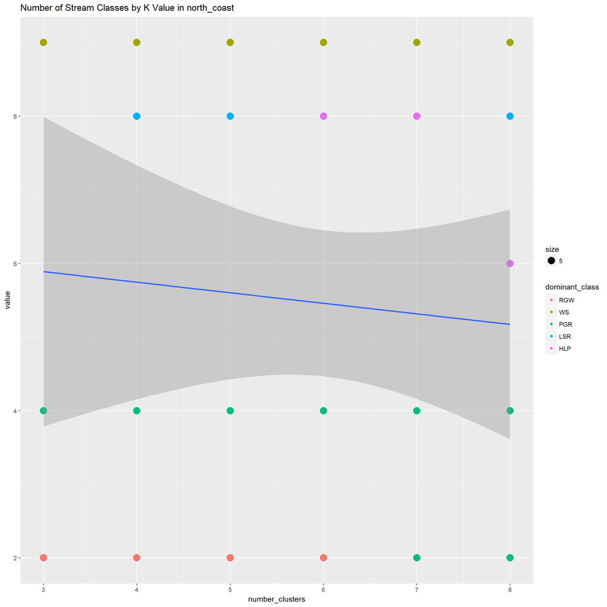

```r
print_dominance_plots(coast_species_info, coast_region_name)
```

```r
coast_species_lists <- species_lists_by_group_dfs(coast_species_info$species_data, coast_region_name)  # species_info$species_data is the data frame for the region
for(df in coast_species_lists){
  show(knitr::kable(df, format="html"))
}
```

| group_1 | group_2 | group_3 |
| --- | --- | --- |
| aculeatus | aculeatus | aculeatus |
| ayersi | ayersi | ayersi |
| conocephalus | brevirostris | conocephalus |
| exilicauda | coerulea | exilicauda |
| grandis | conocephalus | grandis |
| macrolepidotus | grandis | gulosus |
| medirostris | gulosus | kisutch |
| mykiss | kisutch | macrolepidotus |
| occidentalis | klamathensis | medirostris |
| pacificus | luxatus | mykiss |
| richardsoni | medirostris | newberryi |
| symmetricus | mykiss | occidentalis |
| transmontanus | newberryi | pacificus |
| traskii | occidentalis | richardsoni |
| tridentata | richardsoni | symmetricus |
| NA | similis | thaleichthys |
| NA | snyderi | transmontanus |
| NA | thaleichthys | traskii |
| NA | transmontanus | tridentata |
| NA | tridentata | tshawytscha |
| NA | tshawytscha | NA |

| group_1 | group_2 | group_3 | group_4 |
| --- | --- | --- | --- |
| aculeatus | aculeatus | aculeatus | aculeatus |
| ayersi | ayersi | ayersi | ayersi |
| conocephalus | brevirostris | conocephalus | kisutch |
| exilicauda | coerulea | exilicauda | klamathensis |
| grandis | conocephalus | grandis | medirostris |
| macrolepidotus | grandis | gulosus | mykiss |
| medirostris | gulosus | kisutch | newberryi |
| mykiss | kisutch | macrolepidotus | richardsoni |
| occidentalis | klamathensis | medirostris | similis |
| pacificus | luxatus | mykiss | thaleichthys |
| richardsoni | medirostris | newberryi | transmontanus |
| symmetricus | mykiss | occidentalis | tridentata |
| transmontanus | newberryi | pacificus | tshawytscha |
| traskii | occidentalis | richardsoni | NA |
| tridentata | richardsoni | symmetricus | NA |
| NA | similis | thaleichthys | NA |
| NA | snyderi | transmontanus | NA |
| NA | thaleichthys | traskii | NA |
| NA | transmontanus | tridentata | NA |
| NA | tridentata | tshawytscha | NA |
| NA | tshawytscha | NA | NA |

| group_1 | group_2 | group_3 | group_4 | group_5 |
| --- | --- | --- | --- | --- |
| aculeatus | aculeatus | aculeatus | aculeatus | aculeatus |
| ayersi | ayersi | ayersi | ayersi | ayersi |
| conocephalus | brevirostris | conocephalus | kisutch | brevirostris |
| exilicauda | coerulea | exilicauda | klamathensis | conocephalus |
| grandis | kisutch | grandis | medirostris | grandis |
| macrolepidotus | klamathensis | gulosus | mykiss | gulosus |
| medirostris | luxatus | kisutch | newberryi | kisutch |
| mykiss | medirostris | macrolepidotus | richardsoni | medirostris |
| occidentalis | mykiss | medirostris | similis | mykiss |
| pacificus | newberryi | mykiss | thaleichthys | newberryi |
| richardsoni | richardsoni | newberryi | transmontanus | occidentalis |
| symmetricus | similis | occidentalis | tridentata | richardsoni |
| transmontanus | snyderi | pacificus | tshawytscha | similis |
| traskii | transmontanus | richardsoni | NA | thaleichthys |
| tridentata | tridentata | symmetricus | NA | transmontanus |
| NA | tshawytscha | thaleichthys | NA | tridentata |
| NA | NA | transmontanus | NA | tshawytscha |
| NA | NA | traskii | NA | NA |
| NA | NA | tridentata | NA | NA |
| NA | NA | tshawytscha | NA | NA |

| group_1 | group_2 | group_3 | group_4 | group_5 | group_6 |
| --- | --- | --- | --- | --- | --- |
| aculeatus | brevirostris | aculeatus | aculeatus | aculeatus | aculeatus |
| ayersi | coerulea | ayersi | ayersi | ayersi | ayersi |
| conocephalus | klamathensis | conocephalus | kisutch | brevirostris | brevirostris |
| exilicauda | luxatus | exilicauda | klamathensis | conocephalus | coerulea |
| grandis | snyderi | grandis | medirostris | grandis | kisutch |
| macrolepidotus | NA | gulosus | mykiss | gulosus | klamathensis |
| medirostris | NA | kisutch | newberryi | kisutch | luxatus |
| mykiss | NA | macrolepidotus | richardsoni | medirostris | medirostris |
| occidentalis | NA | medirostris | similis | mykiss | mykiss |
| pacificus | NA | mykiss | thaleichthys | newberryi | newberryi |
| richardsoni | NA | newberryi | transmontanus | occidentalis | richardsoni |
| symmetricus | NA | occidentalis | tridentata | richardsoni | similis |
| transmontanus | NA | pacificus | tshawytscha | similis | snyderi |
| traskii | NA | richardsoni | NA | thaleichthys | transmontanus |
| tridentata | NA | symmetricus | NA | transmontanus | tridentata |
| NA | NA | thaleichthys | NA | tridentata | tshawytscha |
| NA | NA | transmontanus | NA | tshawytscha | NA |
| NA | NA | traskii | NA | NA | NA |
| NA | NA | tridentata | NA | NA | NA |
| NA | NA | tshawytscha | NA | NA | NA |

| group_1 | group_2 | group_3 | group_4 | group_5 | group_6 | group_7 |
| --- | --- | --- | --- | --- | --- | --- |
| aculeatus | brevirostris | ayersi | aculeatus | aculeatus | aculeatus | aculeatus |
| ayersi | coerulea | grandis | ayersi | ayersi | ayersi | ayersi |
| conocephalus | klamathensis | gulosus | kisutch | brevirostris | brevirostris | conocephalus |
| exilicauda | luxatus | kisutch | klamathensis | conocephalus | coerulea | exilicauda |
| grandis | snyderi | macrolepidotus | medirostris | grandis | kisutch | grandis |
| macrolepidotus | NA | medirostris | mykiss | gulosus | klamathensis | gulosus |
| medirostris | NA | mykiss | newberryi | kisutch | luxatus | kisutch |
| mykiss | NA | newberryi | richardsoni | medirostris | medirostris | macrolepidotus |
| occidentalis | NA | occidentalis | similis | mykiss | mykiss | medirostris |
| pacificus | NA | richardsoni | thaleichthys | newberryi | newberryi | mykiss |
| richardsoni | NA | symmetricus | transmontanus | occidentalis | richardsoni | newberryi |
| symmetricus | NA | transmontanus | tridentata | richardsoni | similis | occidentalis |
| transmontanus | NA | traskii | tshawytscha | similis | snyderi | pacificus |
| traskii | NA | tridentata | NA | thaleichthys | transmontanus | richardsoni |
| tridentata | NA | tshawytscha | NA | transmontanus | tridentata | symmetricus |
| NA | NA | NA | NA | tridentata | tshawytscha | thaleichthys |
| NA | NA | NA | NA | tshawytscha | NA | transmontanus |
| NA | NA | NA | NA | NA | NA | traskii |
| NA | NA | NA | NA | NA | NA | tridentata |
| NA | NA | NA | NA | NA | NA | tshawytscha |

| group_1 | group_2 | group_3 | group_4 | group_5 | group_6 | group_7 | group_8 |
| --- | --- | --- | --- | --- | --- | --- | --- |
| aculeatus | brevirostris | ayersi | aculeatus | aculeatus | aculeatus | aculeatus | brevirostris |
| ayersi | coerulea | grandis | ayersi | ayersi | ayersi | ayersi | coerulea |
| conocephalus | klamathensis | gulosus | kisutch | brevirostris | kisutch | conocephalus | kisutch |
| exilicauda | luxatus | kisutch | klamathensis | conocephalus | medirostris | exilicauda | klamathensis |
| grandis | snyderi | macrolepidotus | medirostris | grandis | mykiss | grandis | luxatus |
| macrolepidotus | NA | medirostris | mykiss | gulosus | newberryi | gulosus | mykiss |
| medirostris | NA | mykiss | newberryi | kisutch | richardsoni | kisutch | similis |
| mykiss | NA | newberryi | richardsoni | medirostris | similis | macrolepidotus | snyderi |
| occidentalis | NA | occidentalis | similis | mykiss | transmontanus | medirostris | tridentata |
| pacificus | NA | richardsoni | thaleichthys | newberryi | tridentata | mykiss | tshawytscha |
| richardsoni | NA | symmetricus | transmontanus | occidentalis | tshawytscha | newberryi | NA |
| symmetricus | NA | transmontanus | tridentata | richardsoni | NA | occidentalis | NA |
| transmontanus | NA | traskii | tshawytscha | similis | NA | pacificus | NA |
| traskii | NA | tridentata | NA | thaleichthys | NA | richardsoni | NA |
| tridentata | NA | tshawytscha | NA | transmontanus | NA | symmetricus | NA |
| NA | NA | NA | NA | tridentata | NA | thaleichthys | NA |
| NA | NA | NA | NA | tshawytscha | NA | transmontanus | NA |
| NA | NA | NA | NA | NA | NA | traskii | NA |
| NA | NA | NA | NA | NA | NA | tridentata | NA |
| NA | NA | NA | NA | NA | NA | tshawytscha | NA |

## South Coast

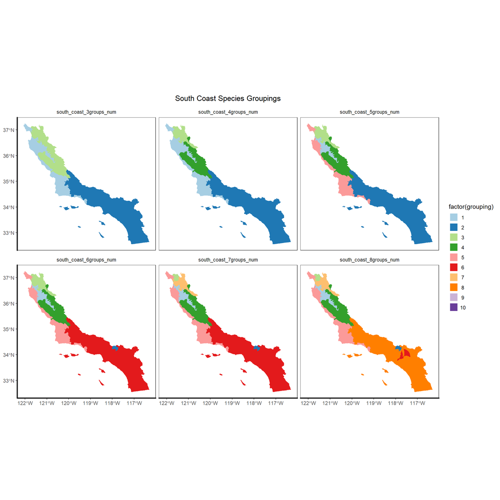

```r
soco_region_name = "south_coast"
soco_species_info <- species_maps(soco_region_name, "South Coast", huc_data)
soco_species_info$region_map  # print the map
```

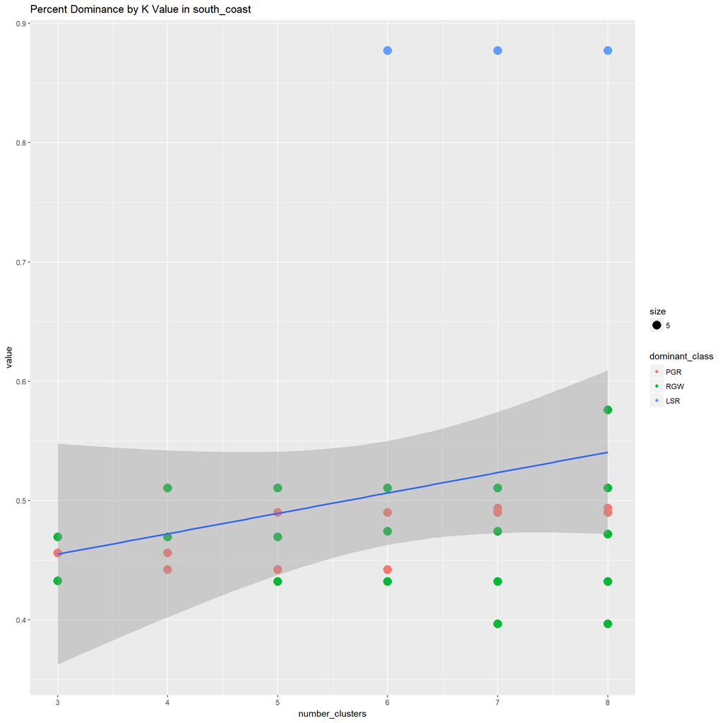

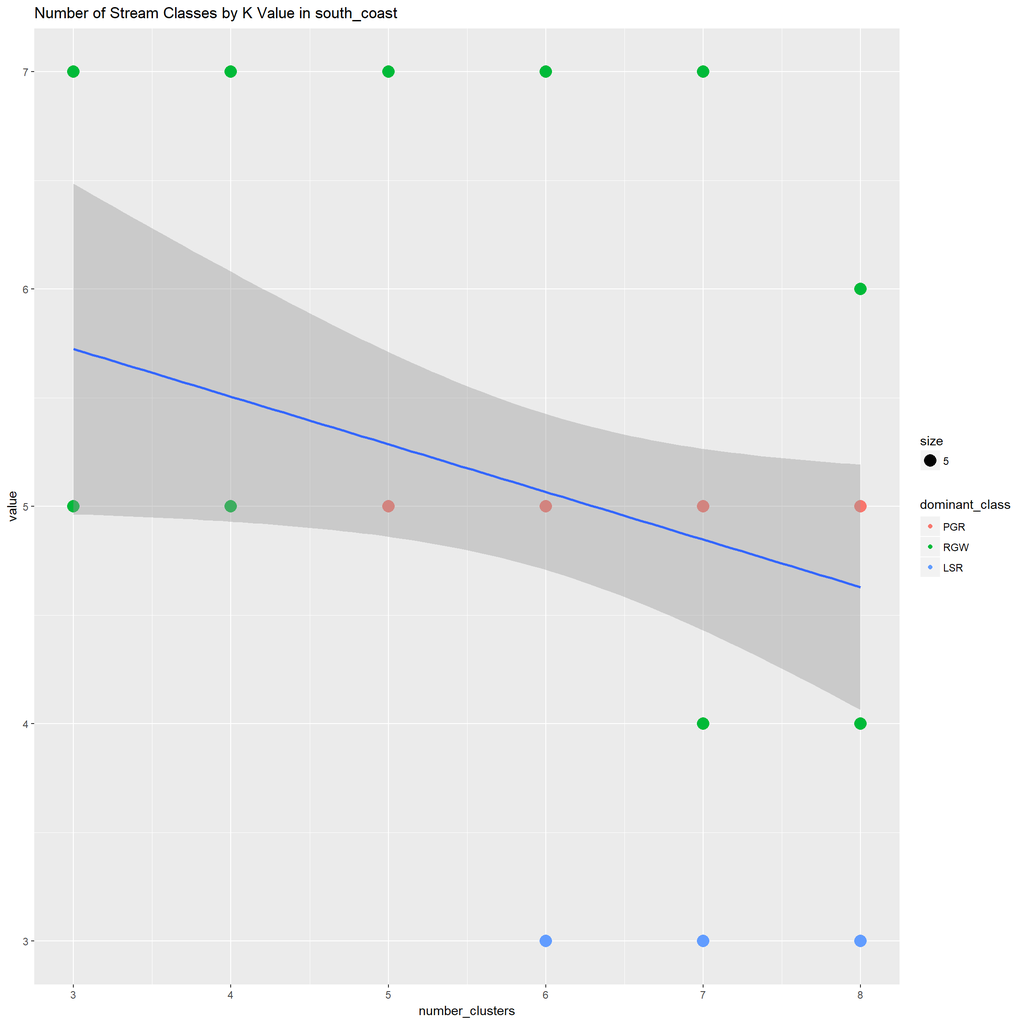

```r
print_dominance_plots(soco_species_info, soco_region_name)
```

```r
soco_species_lists <- species_lists_by_group_dfs(soco_species_info$species_data, soco_region_name)  # species_info$species_data is the data frame for the region
for(df in soco_species_lists){
  show(knitr::kable(df, format="html"))
}
```

| group_1 | group_2 | group_3 |
| --- | --- | --- |
| aculeatus | aculeatus | aculeatus |
| exilicauda | mykiss | exilicauda |
| grandis | newberryi | grandis |
| gulosus | orcutti | gulosus |
| mykiss | osculus | mykiss |
| newberryi | santaanae | newberryi |
| occidentalis | tridentata | occidentalis |
| osculus | NA | osculus |
| symmetricus | NA | symmetricus |
| tridentata | NA | tridentata |

| group_1 | group_2 | group_3 | group_4 |
| --- | --- | --- | --- |
| aculeatus | aculeatus | aculeatus | exilicauda |
| exilicauda | mykiss | exilicauda | grandis |
| grandis | newberryi | grandis | mykiss |
| gulosus | orcutti | gulosus | occidentalis |
| mykiss | osculus | mykiss | tridentata |
| newberryi | santaanae | newberryi | NA |
| occidentalis | tridentata | occidentalis | NA |
| osculus | NA | osculus | NA |
| symmetricus | NA | symmetricus | NA |
| tridentata | NA | tridentata | NA |

| group_1 | group_2 | group_3 | group_4 | group_5 |
| --- | --- | --- | --- | --- |
| aculeatus | aculeatus | aculeatus | exilicauda | aculeatus |
| exilicauda | mykiss | exilicauda | grandis | grandis |
| grandis | newberryi | grandis | mykiss | mykiss |
| gulosus | orcutti | gulosus | occidentalis | newberryi |
| mykiss | osculus | mykiss | tridentata | occidentalis |
| newberryi | santaanae | newberryi | NA | osculus |
| occidentalis | tridentata | occidentalis | NA | symmetricus |
| osculus | NA | osculus | NA | tridentata |
| symmetricus | NA | symmetricus | NA | NA |
| tridentata | NA | tridentata | NA | NA |

| group_1 | group_2 | group_3 | group_4 | group_5 | group_6 |
| --- | --- | --- | --- | --- | --- |
| aculeatus | orcutti | aculeatus | exilicauda | aculeatus | aculeatus |
| exilicauda | osculus | exilicauda | grandis | grandis | mykiss |
| grandis | santaanae | grandis | mykiss | mykiss | newberryi |
| gulosus | NA | gulosus | occidentalis | newberryi | orcutti |
| mykiss | NA | mykiss | tridentata | occidentalis | osculus |
| newberryi | NA | newberryi | NA | osculus | santaanae |
| occidentalis | NA | occidentalis | NA | symmetricus | tridentata |
| osculus | NA | osculus | NA | tridentata | NA |
| symmetricus | NA | symmetricus | NA | NA | NA |
| tridentata | NA | tridentata | NA | NA | NA |

| group_1 | group_2 | group_3 | group_4 | group_5 | group_6 | group_7 |
| --- | --- | --- | --- | --- | --- | --- |
| aculeatus | orcutti | aculeatus | exilicauda | aculeatus | aculeatus | aculeatus |
| exilicauda | osculus | exilicauda | grandis | grandis | mykiss | exilicauda |
| grandis | santaanae | grandis | mykiss | mykiss | newberryi | grandis |
| gulosus | NA | gulosus | occidentalis | newberryi | orcutti | mykiss |
| mykiss | NA | mykiss | tridentata | occidentalis | osculus | newberryi |
| newberryi | NA | newberryi | NA | osculus | santaanae | occidentalis |
| occidentalis | NA | occidentalis | NA | symmetricus | tridentata | osculus |
| osculus | NA | osculus | NA | tridentata | NA | symmetricus |
| symmetricus | NA | symmetricus | NA | NA | NA | tridentata |
| tridentata | NA | tridentata | NA | NA | NA | NA |

| group_1 | group_2 | group_3 | group_4 | group_5 | group_6 | group_7 | group_8 |
| --- | --- | --- | --- | --- | --- | --- | --- |
| aculeatus | orcutti | aculeatus | exilicauda | aculeatus | aculeatus | aculeatus | aculeatus |
| exilicauda | osculus | exilicauda | grandis | grandis | orcutti | exilicauda | mykiss |
| grandis | santaanae | grandis | mykiss | mykiss | osculus | grandis | newberryi |
| gulosus | NA | gulosus | occidentalis | newberryi | santaanae | mykiss | orcutti |
| mykiss | NA | mykiss | tridentata | occidentalis | NA | newberryi | osculus |
| newberryi | NA | newberryi | NA | osculus | NA | occidentalis | santaanae |
| occidentalis | NA | occidentalis | NA | symmetricus | NA | osculus | tridentata |
| osculus | NA | osculus | NA | tridentata | NA | symmetricus | NA |
| symmetricus | NA | symmetricus | NA | NA | NA | tridentata | NA |
| tridentata | NA | tridentata | NA | NA | NA | NA | NA |